# Project 5

Creating data from digital sources

Arman Naderi mnad646

## Part A

I explored job listings for Software developement. I explored this context because I wanted to see job prospects/info about the jobs I want to apply for in the future. I wanted to explore the number of job listings, the titles, and if the jobs offered were contract, part time or full time. I’d like to expand on this in the future by looking at data from seek.co.au and other job posting websites to compare job prospects in NZ compared to other countries.

```r
library(tidyverse)
library(rvest)

# My data context is the job listings for software development.

# Useful webpage information to collect:
#  - Company names
#  - Job locations
#  - Full time or part time
#  - Skills listed on job page
#  - Job post dates

# I wanted to web scrape Linkedin but the robots.txt page disallowed looking at the webpage information I was looking for.
# I tried trademe jobs and it seemed to allow /a/it/programming-development in robots.txt and was not prohibited in the terms of service but it gives ERROR 429 when accessing the URL.
# I tried seek and it allowed job searches in robots.txt and in the terms of service.


url = "https://www.seek.co.nz/Software-Engineer-jobs"

page = read_html(url)

# Find ids and classes avaliable to use.
list = page %>%
  html_nodes("*") %>%
  html_attr("id") %>%
  unique()

contract_or_full_time = page %>%
  html_elements("p") %>%
  html_text2()

job_title = page %>%
  html_elements("h3") %>%
  html_text2()


job_listing_dates = page %>%
  html_elements("[data-automation='jobListingDate']") %>%
  html_text2()

number_job_results = page %>%
  html_elements("#SearchSummary") %>%
  html_text2()



number_job_results
```

```
## [1] "419 jobs"
```

```r
job_listing_dates
```

```
##  [1] "2h ago"  "1d ago"  "1d ago"  "1d ago"  "1d ago"  "7h ago"  "6d ago"
##  [8] "1d ago"  "9d ago"  "8d ago"  "6d ago"  "2d ago"  "2d ago"  "6d ago"
## [15] "2d ago"  "6d ago"  "2d ago"  "6d ago"  "12d ago" "8d ago"
```

```r
job_title
```

```
##  [1] "Junior Developer"
##  [2] "Software Engineer - Backend"
##  [3] "Software Engineer"
##  [4] "Junior Software Integration Engineer"
##  [5] "Software Engineer"
##  [6] "Sr Software Engineer, Full-Stack"
##  [7] "Software Engineer"
##  [8] "Software Engineer"
##  [9] "Software Engineer"
## [10] "Software Engineer"
## [11] "Software Engineer"
## [12] "Dev Ops Software Engineer"
## [13] "Software Engineer"
## [14] "Junior Developer"
## [15] "Embedded Software Engineer"
## [16] "Senior Software Engineer (Flutter)"
## [17] "Senior Software Engineer (Front End)"
## [18] "Senior .net Software Engineer"
## [19] "Practice Lead - Software Engineer"
## [20] "Junior Developer"
## [21] "Security Software Engineer"
## [22] "Developer (Graduate / Junior)"
## [23] "Select a job"
```

```r
contract_or_full_time
```

```
##  [1] "This is a Full time job"     "This is a Full time job"
##  [3] "This is a Full time job"     "This is a Full time job"
##  [5] "This is a Full time job"     "This is a Full time job"
##  [7] "This is a Full time job"     "This is a Full time job"
##  [9] "This is a Full time job"     "This is a Full time job"
## [11] "This is a Contract/Temp job" "This is a Full time job"
## [13] "This is a Full time job"     "This is a Full time job"
## [15] "This is a Full time job"     "This is a Full time job"
## [17] "This is a Full time job"     "This is a Full time job"
## [19] "This is a Full time job"     "This is a Full time job"
## [21] "This is a Full time job"     "This is a Full time job"
```

## Part B

```r
library(tidyverse)
library(rvest)

# I have selected for my minister: Hon Chris Bishop

# Features of the text:
# - The amount of words per paragraph seems to be around 60
# - The number of words per sentence seems to be around 15
# - The length of the words mostly seem to be around 5
# - There seems to be a lot of quotation paragraphs of opinions on certain matters from different people
# - There also seems to be recommendations set out in bullet points
# - Majority of sentences and paragraphs are formal like a report.
# - There is a lot of words like 'fiscal' or 'budget' and other monetary terms used throughout his releases.

url <- "https://www.beehive.govt.nz/minister/hon-chris-bishop"

pages <- read_html(url) %>%
  html_elements(".release__wrapper") %>%
  html_elements("h2") %>%
  html_elements("a") %>%
  html_attr("href") %>%
  paste0("https://www.beehive.govt.nz", .)


page_url <- pages[1]
print(page_url)

page <- read_html(page_url)

release_title <- page %>%
  html_elements(".article__title") %>%
  html_text2()

release_content <- page %>%
  html_elements(".prose.field.field--name-body.field--type-text-with-summary.field--label-hidden.field--item") %>%
  html_text2()
# Both work


get_release <- function(page_url){
  Sys.sleep(2)
  # print the page_url so if things go wrong
  # we can see which page caused issues
  print(page_url)
  page <- read_html(page_url)

  # add code to scrape the release title and release content
  release_title <- page %>%
    html_elements(".article__title") %>%
    html_text2()

  release_content <- page %>%
    html_elements(".prose.field.field--name-body.field--type-text-with-summary.field--label-hidden.field--item") %>%
    html_text2()

  # add code to return a tibble created using these data objects
  tibble(words = release_content, release_title)
}

release_data <- map_df(pages, get_release)



extra_data = release_data %>%
  mutate(title_length = str_count(release_title),
         number_of_sentences = str_count(words, "\\."),
         includes_recommendations = str_detect(str_to_lower(words), 'recommend'),
         includes_monetary_info = str_detect(str_to_lower(words), "budget|fiscal|finance|deposit|grant|fund"))

mean_title_length = mean(extra_data$title_length)

mean_num_sentences = mean(extra_data$number_of_sentences)

counts_includes_recommendation = extra_data %>%
  group_by(includes_recommendations) %>%
  summarise(count = n())


# 30% include recommmendations
percentage_includes_recommendation = counts_includes_recommendation %>%
  filter(includes_recommendations == TRUE) %>%
  pull(count) / sum(counts_includes_recommendation$count) * 100


counts_includes_monetary_info = extra_data %>%
  group_by(includes_monetary_info) %>%
  summarise(count = n())


# 50% include monetary info
percentage_includes_monetary_info = counts_includes_monetary_info %>%
  filter(includes_monetary_info == TRUE) %>%
  pull(count) / sum(counts_includes_monetary_info$count) * 100



percentage_includes_recommendation
percentage_includes_monetary_info
mean_title_length
mean_num_sentences
```

The percentage of my chosen Minister’s releases that contain a recommendation is $30$%

The percentage of my chosen Minister’s releases that contain monetary information is $50$%

The mean number of characters in my chosen Minister’s release titles was $49$

The mean number of sentences in my chosen Minister’s release contents were $20$

## Part C

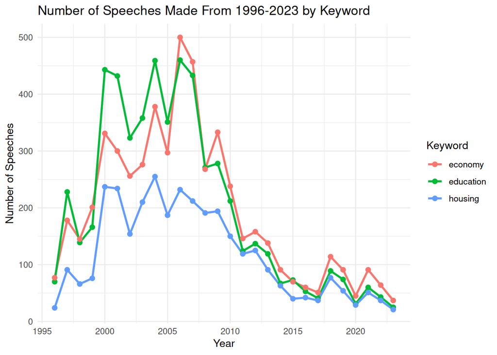

```r
library(tidyverse)
library(rvest)



keywords <- c("education", "housing", "economy")

search1 <- read_html(paste0("https://datalandscapes.online/scrapeable/speeches.php?search=", keywords[1])) %>%
  html_elements(".speech_summary") %>%
  html_text2() %>%
  tibble(keyword = keywords[1],
         results = .) %>%
  separate(results, into = c("year", "num_speeches"), sep = "--") %>%
  mutate(num_speeches = parse_number(num_speeches),
         year = parse_number(year))

search2 <- read_html(paste0("https://datalandscapes.online/scrapeable/speeches.php?search=", keywords[2])) %>%
  html_elements(".speech_summary") %>%
  html_text2() %>%
  tibble(keyword = keywords[2],
         results = .) %>%
  separate(results, into = c("year", "num_speeches"), sep = "--") %>%
  mutate(num_speeches = parse_number(num_speeches),
         year = parse_number(year))

search3 <- read_html(paste0("https://datalandscapes.online/scrapeable/speeches.php?search=", keywords[3])) %>%
  html_elements(".speech_summary") %>%
  html_text2() %>%
  tibble(keyword = keywords[3],
         results = .) %>%
  separate(results, into = c("year", "num_speeches"), sep = "--") %>%
  mutate(num_speeches = parse_number(num_speeches),
         year = parse_number(year))

combined_search = bind_rows(search1, search2, search3)

speeches_government = read_csv("https://docs.google.com/spreadsheets/d/e/2PACX-1vRHTFJcFmsIkjaFUCEwFWASaBOAR4X2Upx66C5Bhgc_WNc2JxxdRbbvyoewmvt_EjNdCNZZzzkENwLg/pub?gid=0&single=true&output=csv")


speech_data = left_join(speeches_government, combined_search, by = "year")


plot = ggplot(speech_data, aes(x = year, y = num_speeches, color = keyword)) +
  geom_line(size = 1) +

  geom_point(size = 2) +
  labs(title = "Number of Speeches Made From 1996-2023 by Keyword",
       x = "Year", y = "Number of Speeches", color = "Keyword") +
  theme_minimal()

plot
```

## Learning reflection

I learned how to use use the new library, rvest, and it’s functions to scrape data from the web. I also learned more about how websites are organised, like using classes or ids or headers, and how to identify such in inspect element to use for web scraping.

I would like to further learn more about web scraping, specifically how to look at specific job positings on websites like Linkedin and be able to take out key words for that job. For example, using web scraping to find the technologies that are used by a developer and being able to compile a table that shows the most commonly listed technologies that is shown for the given developer’s job listings. This would help us focus on the technologies that companies actually look for in their hirings.

# Self review

I believe that I have further enhanced my ability to code, specifically using R within this course. The programming concepts I have learned have allowed me to organise data and be able to use existing data/variables to create and modify new ones. I have also learned about HTML and how to select specific data from websites to scrape, and therefore use in reports to find discover new insights; this is done in an ethical and considerate manner, by which we respect the terms/conditions of the websites that we choose to scrape the data from. This manner also goes for data collection of individuals that, knowing the extent in how their data will be used, choose to participate in surveys created by us.